# Chapter 5 — Categorical data: chi-square and Fisher’s exact tests

Counts in categories in Molecular Biosciences

**Biostatistics · Molecular Biosciences**  
This chapter introduces tests for **categorical data**: outcomes that are counts of categories (resistant or susceptible) rather than measurements. One experiment is followed from start to finish: whether a mutation in a bacterial gene is associated with antibiotic resistance.

## Learning goals

By the end of this chapter, you should be able to:

- recognise when the data are counts in categories and arrange them in a contingency table;
- choose between the chi-square test, Fisher’s exact test and McNemar’s test;
- state the hypotheses and assumptions of the test of independence;
- calculate expected counts and the $\chi^2$ statistic;
- explain the exact p-value and when the chi-square approximation is unreliable;
- use standardized residuals, the odds ratio and its confidence interval;
- run the analysis in R and report the result.

## Biological question: is an efflux-pump mutation linked to resistance?

Ciprofloxacin is an antibiotic that bacteria can resist by pumping it out of the cell. The *acrR* gene encodes a repressor of the AcrAB-TolC efflux pump: when *acrR* is mutated, the pump is produced in excess and more drug is expelled. A laboratory collected **50 clinical isolates of *E. coli*, one per patient**, sequenced *acrR* and tested each isolate for ciprofloxacin resistance (disc diffusion: a clear zone around the antibiotic disc means susceptible). **This one experiment is used throughout the chapter.**

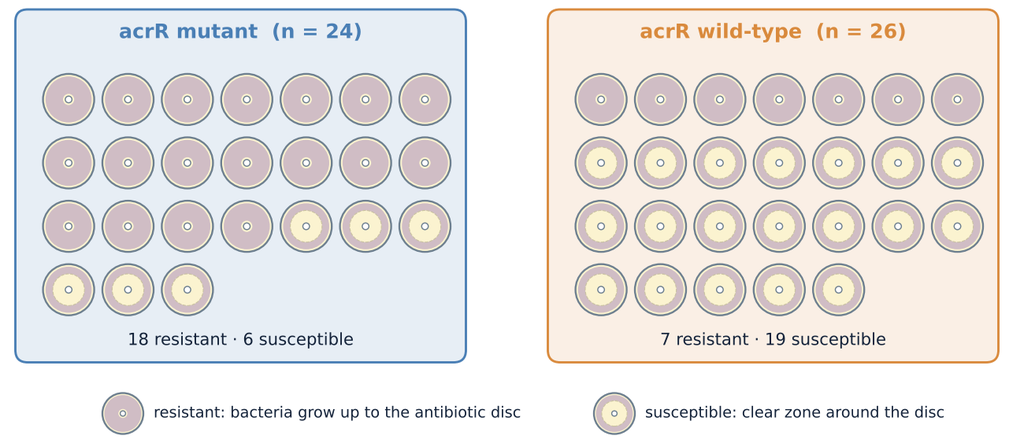

Fifty isolates tested on agar plates: resistant isolates grow up to the antibiotic disc, susceptible isolates show a clear zone.

Each isolate is classified twice: *acrR* **mutant or wild-type**, and ciprofloxacin **resistant or susceptible**. Counting isolates in each combination gives a 2 × 2 **contingency table**:

|  | Resistant | Susceptible | Total |
| --- | --- | --- | --- |
| *acrR* mutant | 18 | 6 | 24 |
| *acrR* wild-type | 7 | 19 | 26 |
| **Total** | 25 | 25 | 50 |

**What to tell the analyst when you submit data.** Give the **counts**, not only percentages. Say what one row of your data is (here, one isolate from one patient), which variable is the group and which is the outcome, and how the outcome was defined (for example the breakpoint used for resistance). State whether several isolates came from the same patient or the same outbreak: they are **not independent**. If the same subjects were measured twice, say so, because that is a paired design.

## Choosing the method

The tests in the previous chapters rank **measurements**. Here the data are **counts of subjects in categories**, so ranks are not used. The right test depends on how the subjects are linked.

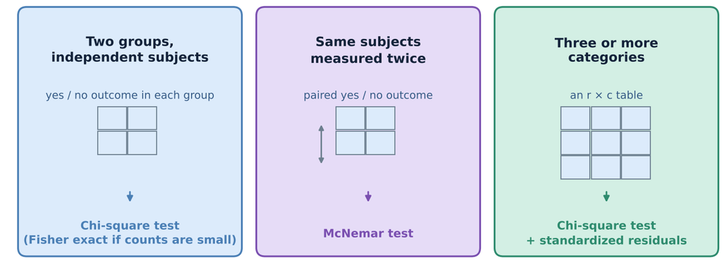

Choosing a test for categorical data: independent groups, paired observations, or a table with more categories.

- **Chi-square test of independence:** each subject is counted once, in one row and one column.
- **Fisher’s exact test:** the same question as the chi-square test, but an exact calculation, used when counts are small.
- **McNemar’s test:** the same subjects are classified twice (for example before and after treatment), so the two classifications are linked.

## Assumptions and hypotheses

- Each subject is counted **once**, in exactly one cell, and subjects are independent of each other.
- The data are **counts** (not percentages or means).
- For the chi-square approximation, **expected** counts should be large enough: a common rule is at least 5 in every cell. Otherwise use Fisher’s exact test.

The hypotheses in words and symbols:

$$H_0:\ \text{resistance is independent of }acrR\text{ status (same
proportion resistant in both groups)}$$

$$H_1:\ \text{the proportion resistant differs between mutant and
wild-type isolates}$$

### The test is omnibus and non-directional

Rejecting $H_0$ shows that the two variables are associated, not **in which direction** or how strongly: that comes from the proportions, the odds ratio and its confidence interval. In R:

```r
chisq.test(tab, correct = FALSE)
```

## Worked example: expected counts and the chi-square statistic

If resistance were unrelated to the mutation, the proportion resistant would be the same in both groups: $25/50=50\%$. The expected count in each cell follows from the totals:

$$E_{ij}=\frac{(\text{row total}_i)\times(\text{column total}_j)}{N}$$

For the mutant isolates that are resistant, $E_{11}=24\times25/50=12$. Each cell then contributes $(O-E)^2/E$:

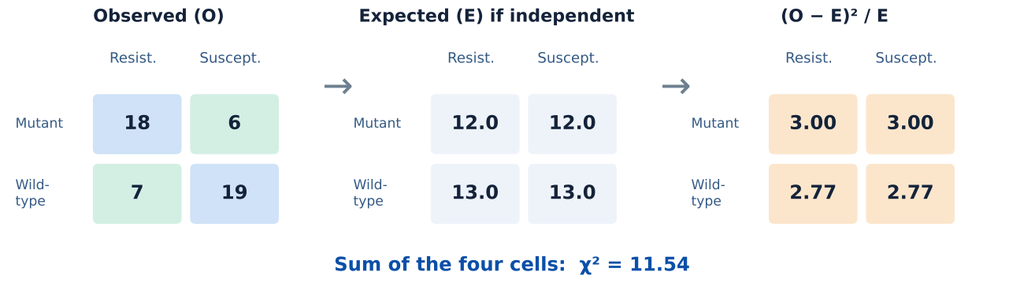

Observed counts, expected counts if resistance and genotype were independent, and the contribution of each cell.

$$\chi^2=\sum_{i,j}\frac{\left(O_{ij}-E_{ij}\right)^2}{E_{ij}}=\frac{(18-12)^2}{12}+\frac{(6-12)^2}{12}+\frac{(7-13)^2}{13}+\frac{(19-13)^2}{13}=11.54$$

If the variables were independent, observed and expected counts would be close and $\chi^2$ would be small. Here every cell is 6 isolates away from its expected count.

## Exact p-value: Fisher’s exact test

With the row and column totals fixed (24 mutants, 26 wild-type, 25 resistant, 25 susceptible), the number of resistant isolates among the 24 mutants can only take certain values. If resistance were unrelated to the mutation, its probability follows the **hypergeometric distribution**: it is like drawing 24 isolates at random from the 50 and counting how many are resistant.

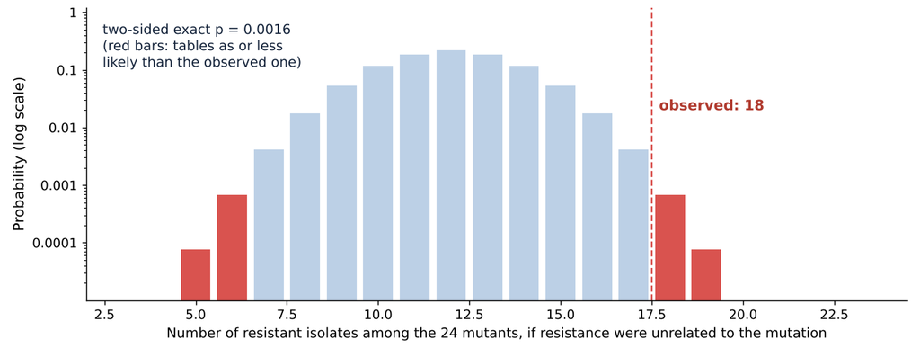

Exact distribution of the number of resistant mutants under independence, on a log scale; the observed value 18 is marked.

The probability of exactly 18 is $0.0007$. The **two-sided exact p-value** adds the probabilities of all tables that are as likely or less likely than the observed one (the red bars, in both tails):

$$p_{\text{exact}}=0.0016$$

### What changes when the counts are small

The chi-square p-value is an **approximation** that is accurate when expected counts are large. Check the expected counts first (`test$expected` in R). If any is below 5 in a 2 × 2 table, report Fisher’s exact test.

## Chi-square approximation

For larger samples, $\chi^2$ is compared with a **chi-square distribution** with degrees of freedom equal to the number of independent cells:

$$df=(r-1)(c-1)=(2-1)(2-1)=1$$

The p-value is the upper-tail probability:

$$p=P\left(\chi^2_{1}\ge 11.54\right)=0.0007$$

The chi-square distribution has mean $df$ and variance $2\,df$. Some programs apply **Yates’ continuity correction** to 2 × 2 tables, subtracting 0.5 from each $|O-E|$: this gives $\chi^2=9.70$ and $p=0.0018$. The correction is conservative; in R it is the default, which is why the examples here set `correct = FALSE`. Say which version you report.

### Reproducing the chi-square test in R

```r
chisq.test(tab, correct = FALSE)
```

R reports $\chi^2=11.54$, $df=1$ and $p=0.0007$. The exact p-value (0.0016) is slightly larger because the exact distribution is discrete.

## Which cells drive the association? Standardized residuals

A significant result says the variables are associated, not which cells are responsible. In larger tables, look at the **adjusted standardized residual** of each cell:

$$z_{ij}=\frac{O_{ij}-E_{ij}}{\sqrt{E_{ij}\left(1-\dfrac{r_i}{N}\right)\left(1-\dfrac{c_j}{N}\right)}}$$

Values beyond about $\pm2$ mark cells with clearly more (positive) or fewer (negative) observations than expected under independence. For our table:

- **Mutant, resistant:** $z=+3.40$ (more resistant mutants than expected)
- **Mutant, susceptible:** $z=-3.40$
- **Wild-type, resistant:** $z=-3.40$ (fewer resistant wild-type isolates than expected)
- **Wild-type, susceptible:** $z=+3.40$

In a 2 × 2 table all four residuals have the same size, so they only restate the single comparison. They become informative in tables with three or more categories, where the same test is applied to the full $r\times c$ table.

## Effect size: odds ratio and risk difference

The p-value says whether an association exists; the **effect size** says how strong it is. In the mutant group $75\%$ of isolates are resistant, against $27\%$ in wild-type: a difference of $48$ percentage points. The **odds ratio** compares the odds of resistance in the two groups:

$$\text{OR}=\frac{18/6}{7/19}=\frac{18\times19}{6\times7}=8.1$$

An odds ratio of 1 means no association. The confidence interval is computed on the log scale:

$$\text{95\%
CI}=\exp\!\left(\ln\text{OR}\pm1.96\sqrt{\tfrac1{18}+\tfrac1{6}+\tfrac1{7}+\tfrac1{19}}\right)=2.3\text{
to }28.9$$

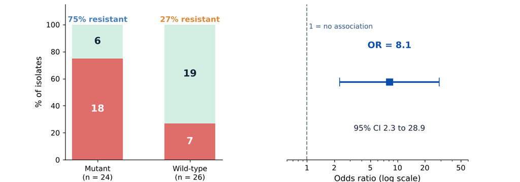

Left: share of resistant isolates in each group. Right: the odds ratio with its 95% confidence interval on a log scale.

**Editable R code**

Change the data or code, then select Run R.

WebR has not loaded yet.

```
R output will appear here.
```

### R interpretation exercise: a small study with low expected counts

Select **Load small-sample exercise** above, or copy the code into desktop R. In this smaller study 4 of 5 mutants and 1 of 6 wild-type isolates are resistant.

## Practice questions

Answer the questions online and check the feedback. These questions are formative: use the explanations to review the relevant sections.

**1. Which design calls for a chi-square test of independence?**

- A. The same patients’ isolates classified resistant or susceptible before and after treatment
- B. Isolates from 50 different patients classified by genotype and by resistance
- C. MIC values compared between two groups of isolates
- D. Gene expression in the same donors under three conditions

**2. In the worked example, what is the expected count for resistant mutant isolates?**

- A. 18
- B. 9
- C. 12
- D. 6

**3. What does the null hypothesis of the chi-square test of independence state?**

- A. Resistance and genotype are independent
- B. The mutation causes resistance
- C. All four cell counts are equal
- D. The odds ratio is greater than 1

## Practice questions: calculations and p-values

**4. How many degrees of freedom does the chi-square test have for a 2 × 2 table?**

- A. 4
- B. 3
- C. 2
- D. 1

**5. What does the exact (Fisher) p-value add up?**

- A. The probability of exactly the observed table
- B. The probabilities of tables with the same totals that are as or less likely than the observed one
- C. The squared differences between observed and expected counts
- D. The probability that the odds ratio equals 1

**6. The test gives χ² = 11.54, df = 1, p = 0.0007. What is a correct conclusion?**

- A. The data give strong evidence of an association between genotype and resistance
- B. The mutation causes resistance in every isolate
- C. The two variables are independent
- D. The result is not significant at 5%

## Practice questions: small samples and interpretation

**7. A small study has expected counts of 2.27, 2.73, 2.73 and 3.27. Which test should you report?**

- A. Chi-square with a larger df
- B. McNemar test
- C. Fisher’s exact test
- D. Kruskal–Wallis test

**8. The odds ratio is 8.1 with a 95% CI of 2.3 to 28.9. What does this mean?**

- A. 8.1% of mutants are resistant
- B. The odds of resistance are about 8 times higher in mutants, with a wide, imprecise interval
- C. The mutation is 8 times more common than the wild type
- D. The result is not significant because the interval is wide

**9. Several isolates were taken from each patient. Which assumption of the chi-square and Fisher tests is broken?**

- A. Independence: isolates from the same patient are not independent observations
- B. The expected counts will be too large
- C. The odds ratio cannot be calculated
- D. Nothing: more isolates always improve the test

**Interpretation reminder.** A significant association is not proof of causation: resistance and the mutation can both be linked to bacterial lineage. Report counts, the effect size and its confidence interval, and say whether isolates were independent.

## Student notes

Use this space to record your interpretation, questions or reminders. Notes are saved locally in the current browser and device; they are not synchronised between devices.

Notes are stored locally in this browser.

## Chapter recap: the complete infographic

The infographic below summarises the whole chapter. Use it to review the biological question, test choice, assumptions, hypotheses, expected counts, $\chi^2$, p-values, residuals, effect size and interpretation.

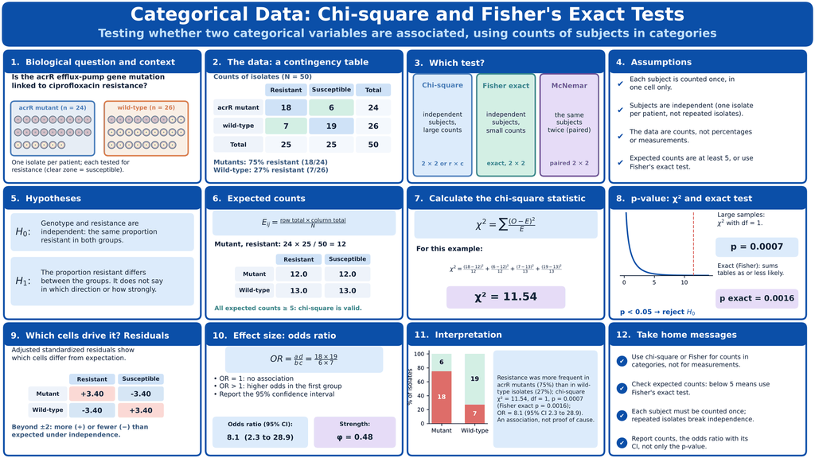

Categorical data chapter infographic recap with twelve panels

**End of Chapter 5 · Biostatistics for Molecular Biosciences**